# Two continuous endpoints

This vignette describes the analysis of a proof-of-concept (PoC) study with two continuous endpoints (Yamaguchi et al., submitted). `vignette("two-binary")` describes the regions and the criteria for two endpoints, which are the same here.

## Model

In group $k$ ($k = t, c$), the responses of a subject on the two endpoints have a bivariate normal distribution $N_2(\mu_k, \Sigma_k)$, and the data are summarized by the number of subjects, the vector of sample means and the sample covariance matrix (`data_continuous2()`). With the Normal-Inverse-Wishart prior (`prior_niw()`),
$$\mu_k \mid \Sigma_k \sim N_2(\mu_0, \Sigma_k /
\kappa_0), \qquad
\Sigma_k \sim \textrm{Inv-Wishart}(\nu_0, \Lambda_0),$$
the posterior distribution has the same form with parameters $(\mu_n, \kappa_n, \nu_n, \Lambda_n)$, and the mean has the bivariate t distribution with $\nu_n - 1$ degrees of freedom, location $\mu_n$ and scale matrix $\Lambda_n / \{\kappa_n (\nu_n - 1)\}$. With the vague prior $p(\mu, \Sigma) \propto |\Sigma|^{-3/2}$ (`prior_vague()`), the posterior distribution of the mean is $t_{n - 2}(\bar y, S / \{n (n - 2)\})$, where $S$ is $n - 1$ times the sample covariance matrix.

For the predictive criterion, the mean of $m$ future subjects has the same distribution with the scale matrix $(1 / \kappa_n + 1 / m) \Lambda_n / (\nu_n - 1)$. Version 0.1.0 of the package used $(1 + \kappa_n) \Lambda_n / \{\kappa_n (\nu_n - 1) m\}$, which treats the future subjects as independent draws from the predictive distribution of one subject.

The treatment effects are $\theta_j = \mu_{tj} - \mu_{cj}$ ($j = 1, 2$), and the probabilities of the regions are computed by one of two methods (argument `method` of `design_continuous2()`):

- `"MM"` (the default): the difference of the two bivariate t distributions is approximated by a bivariate t distribution with matched moments (Yamaguchi, Homma, Takeda and Maruo, submitted, Theorem 3), whose rectangle probabilities are computed by numerical integration, also for non-integer degrees of freedom; it requires more than 4 degrees of freedom in both groups;
- `"MC"`: Monte Carlo simulation with `nMC` draws from each distribution.

## Decision for observed data

The second case study of Yamaguchi et al. (submitted) has 30 subjects per group, Normal-Inverse-Wishart priors, $\theta_{TV} = (10, 2)$ and $\theta_{MAV} = (5, 1)$. Here the thresholds are $\gamma_{go} = \gamma_{nogo} = 0.6$ (the article calibrates its own thresholds), and the observed data are illustrative:

```r
L0 <- matrix(c(80^2, 15, 15, 6^2), 2, 2)
crit <- criterion_posterior(theta_tv = c(10, 2), theta_mav = c(5, 1),
                            gamma_go = 0.6, gamma_nogo = 0.6)
des <- design_continuous2(
  n_t = 30, n_c = 30,
  prior_t = prior_niw(mu0 = c(0, 1), kappa0 = 0.1, nu0 = 4, Lambda0 = L0),
  prior_c = prior_niw(mu0 = c(-10, -1), kappa0 = 0.1, nu0 = 4,
                      Lambda0 = L0),
  criterion = crit
)
data_t <- data_continuous2(30, mean = c(12, 3),
                           cov = matrix(c(6400, 190, 190, 36), 2, 2))
data_c <- data_continuous2(30, mean = c(-10, -1),
                           cov = matrix(c(5600, 150, 150, 42), 2, 2))
dec <- qdm_decide(des, data_t = data_t, data_c = data_c)
dec
```

```
#> Decision: Go
#>   Go:   P(regions {1} | data) = 0.6788 (threshold 0.6, met)
#>   NoGo: P(regions {9} | data) = 0.01376 (threshold 0.6, not met)
#> Region probabilities: R1 = 0.6788, R2 = 0.03923, R3 = 0.01266, R4 = 0.06662, R5 = 0.007634, R6 = 0.003074, R7 = 0.1521, R8 = 0.02611, R9 = 0.01376
#> Posterior distributions
#>   Treatment: mean ~ t(df = 33, location = (11.960, 2.993), scale = (193.310, 5.565; 5.565, 1.088))
#>   Control:   mean ~ t(df = 33, location = (-10, -1), scale = (169.939, 4.394; 4.394, 1.262))
```

The decision is Go. Monte Carlo simulation gives similar probabilities of the regions:

```r
des_mc <- design_continuous2(
  n_t = 30, n_c = 30,
  prior_t = prior_niw(mu0 = c(0, 1), kappa0 = 0.1, nu0 = 4, Lambda0 = L0),
  prior_c = prior_niw(mu0 = c(-10, -1), kappa0 = 0.1, nu0 = 4,
                      Lambda0 = L0),
  criterion = crit, method = "MC", nMC = 10000
)
dec_mc <- qdm_decide(des_mc, data_t = data_t, data_c = data_c, seed = 1)
rbind(MM = dec$prob_regions, MC = dec_mc$prob_regions)
```

```
#>           R1         R2         R3         R4          R5          R6        R7
#> MM 0.6787969 0.03922545 0.01265575 0.06661762 0.007633996 0.003073625 0.1521253
#> MC 0.6803000 0.03950000 0.01230000 0.06970000 0.007800000 0.002800000 0.1507000
#>            R8         R9
#> MM 0.02611161 0.01375978
#> MC 0.02520000 0.01170000
```

## Hypothetical control

For a study without a concurrent control group, `hypothetical(mean, r)` gives the control mean the distribution of the treatment mean with location `mean` and the scale matrix multiplied by `r`. The prior of the control group is then not used and is left `NULL`:

```r
des_hyp <- design_continuous2(
  n_t = 30, n_c = 0,
  prior_t = prior_niw(mu0 = c(0, 1), kappa0 = 0.1, nu0 = 4, Lambda0 = L0),
  criterion = crit,
  hypothetical_c = hypothetical(mean = c(-10, -1), r = 1)
)
dec_hyp <- qdm_decide(des_hyp, data_t = data_t)
dec_hyp
```

```
#> Decision: Go
#>   Go:   P(regions {1} | data) = 0.6812 (threshold 0.6, met)
#>   NoGo: P(regions {9} | data) = 0.0132 (threshold 0.6, not met)
#> Region probabilities: R1 = 0.6812, R2 = 0.03398, R3 = 0.009255, R4 = 0.06648, R5 = 0.007249, R6 = 0.00251, R7 = 0.1584, R8 = 0.02774, R9 = 0.0132
#> Posterior distributions
#>   Treatment: mean ~ t(df = 33, location = (11.960, 2.993), scale = (193.310, 5.565; 5.565, 1.088))
#>   Control:   mean ~ t(df = 33, location = (-10, -1), scale = (193.310, 5.565; 5.565, 1.088))
```

## Fixed control

With `fixed_c`, the control means are known values, for example the means of the standard of care reported in the literature. The probabilities of the regions are then those of the bivariate t distribution of the treatment mean, which are computed by numerical integration for any degrees of freedom, so `method` is not used:

```r
des_fix <- design_continuous2(
  n_t = 30, n_c = 0,
  prior_t = prior_niw(mu0 = c(0, 1), kappa0 = 0.1, nu0 = 4, Lambda0 = L0),
  criterion = crit, fixed_c = c(-10, -1)
)
dec_fix <- qdm_decide(des_fix, data_t = data_t)
dec_fix
```

```
#> Decision: Go
#>   Go:   P(regions {1} | data) = 0.7864 (threshold 0.6, met)
#>   NoGo: P(regions {9} | data) = 0.001807 (threshold 0.6, not met)
#> Region probabilities: R1 = 0.7864, R2 = 0.01441, R3 = 0.001277, R4 = 0.0778, R5 = 0.004079, R6 = 0.0004697, R7 = 0.1035, R8 = 0.0103, R9 = 0.001807
#> Posterior distributions
#>   Treatment: mean ~ t(df = 33, location = (11.960, 2.993), scale = (193.310, 5.565; 5.565, 1.088))
#>   Control:   fixed values (-10, -1)
```

The control means are not uncertain, so the probability of the Go region is 0.786, compared with 0.681 for the hypothetical control with the same location.

## Operating characteristics

`qdm_oc()` simulates the sample means and the matrix of sums of squares and cross-products of `nsim` studies under each scenario, with the same random numbers for all scenarios. A scenario gives the means, standard deviations and correlation of the two endpoints in each group. To keep this vignette quick, 1000 studies are simulated per scenario (the default is 10000):

```r
effects <- expand.grid(theta1 = c(0, 10, 20), theta2 = c(0, 2, 4))
scen <- data.frame(mu_t1 = -10 + effects$theta1,
                   mu_t2 = -1 + effects$theta2, sd_t1 = 80, sd_t2 = 6,
                   rho_t = 0.3, mu_c1 = -10, mu_c2 = -1, sd_c1 = 80,
                   sd_c2 = 6, rho_c = 0.3)
oc <- qdm_oc(des, scen, nsim = 1000, seed = 1)
oc
```

```
#> Operating characteristics (simulation of 1000 studies; probabilities by moment-matching approximation)
#>  mu_t1 mu_t2 sd_t1 sd_t2 rho_t mu_c1 mu_c2 sd_c1 sd_c2 rho_c    Go  NoGo  Gray
#>    -10    -1    80     6   0.3   -10    -1    80     6   0.3 0.019 0.300 0.681
#>      0    -1    80     6   0.3   -10    -1    80     6   0.3 0.032 0.188 0.780
#>     10    -1    80     6   0.3   -10    -1    80     6   0.3 0.047 0.108 0.845
#>    -10     1    80     6   0.3   -10    -1    80     6   0.3 0.095 0.090 0.815
#>      0     1    80     6   0.3   -10    -1    80     6   0.3 0.153 0.057 0.790
#>     10     1    80     6   0.3   -10    -1    80     6   0.3 0.212 0.034 0.754
#>    -10     3    80     6   0.3   -10    -1    80     6   0.3 0.190 0.012 0.798
#>      0     3    80     6   0.3   -10    -1    80     6   0.3 0.319 0.008 0.673
#>     10     3    80     6   0.3   -10    -1    80     6   0.3 0.468 0.005 0.527
#>  Miss
#>     0
#>     0
#>     0
#>     0
#>     0
#>     0
#>     0
#>     0
#>     0
```

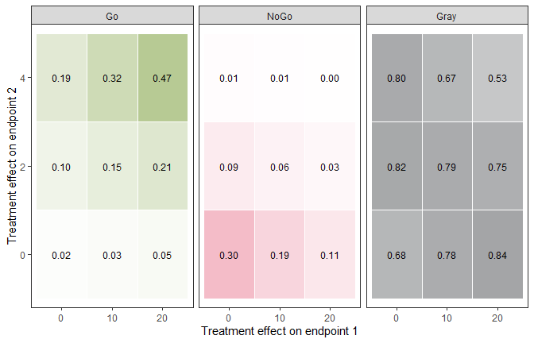

```r
plot(oc)
```

The simulation standard error of the probabilities is at most $0.5 / \sqrt{nsim}$, 0.016 for 1000 studies. The moment-matching approximation is much faster than Monte Carlo estimation of the region probabilities, whose computing time is proportional to `nMC` for every simulated study.

`overlay = TRUE` draws a single heat map of the decision with the highest probability in each cell (see `vignette("two-binary")`), here over a wider range of effects:

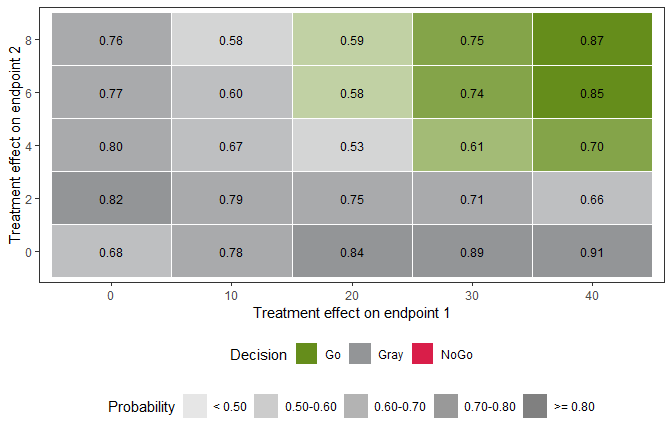

```r
eff_wide <- expand.grid(theta1 = seq(0, 40, by = 10),
                        theta2 = seq(0, 8, by = 2))
scen_wide <- data.frame(mu_t1 = -10 + eff_wide$theta1,
                        mu_t2 = -1 + eff_wide$theta2, sd_t1 = 80,
                        sd_t2 = 6, rho_t = 0.3, mu_c1 = -10, mu_c2 = -1,
                        sd_c1 = 80, sd_c2 = 6, rho_c = 0.3)
plot(qdm_oc(des, scen_wide, nsim = 1000, seed = 1), overlay = TRUE)
```

## Decision boundary

For each observed treatment mean of endpoint 1, `qdm_boundary()` gives the intervals of the observed treatment mean of endpoint 2 that lead to Go, NoGo and Gray decisions, for a given sample covariance matrix, together with the observed differences in means. The ends of the intervals are located by bisection between the values of the grid `mean_t[[2]]`, extended by values far beyond its ends, so an interval can reach beyond the grid. With a concurrent control group, the observed control data are given by `data_c`, and the rows are labeled by the observed difference in means of endpoint 1 (`effect1`), the treatment mean minus the control mean of $-10$; the treatment means 0, 10, 20 and 30 below appear as 10, 20, 30 and 40:

```r
qdm_boundary(des, mean_t = list(c(0, 10, 20, 30), seq(-3, 7, by = 0.25)),
             cov_t = data_t$cov, data_c = data_c)
```

```
#> Decision boundary of a design with two continuous endpoints
#>   n_t = 30
#>   Control data: two continuous endpoints, n = 30, mean = (-10, -1), cov = (5600, 150; 150, 42)
#>
#> Observed treatment mean of endpoint 2
#>   effect1   Gray       Go
#>   10        all        -
#>   20        <= 2.39    >= 2.39
#>   30        <= 1.696   >= 1.696
#>   40        <= 1.489   >= 1.489
#>
#> Observed difference in means of endpoint 2 (control mean -1)
#>   effect1   Gray       Go
#>   10        all        -
#>   20        <= 3.39    >= 3.39
#>   30        <= 2.696   >= 2.696
#>   40        <= 2.489   >= 2.489
```

With more values of endpoint 1, the plot shows the regions of the decisions over the observed differences in means of the two endpoints:

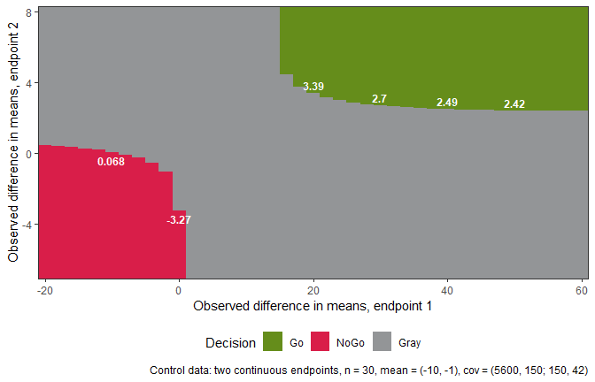

```r
b <- qdm_boundary(des, mean_t = list(seq(-30, 50, by = 2),
                                     seq(-3, 7, by = 0.25)),
                  cov_t = data_t$cov, data_c = data_c)
plot(b)
```

## Calibration of the thresholds

The thresholds are calibrated so that the Go criterion is met with probability at most 0.1 when neither endpoint is improved, and the NoGo criterion with probability at most 0.2 when the effects are 20 and 4:

```r
cal <- qdm_calibrate(des, scenario_go = scen[1, ], scenario_nogo = scen[9, ],
                     target_go = 0.1, target_nogo = 0.2, nsim = 1000,
                     seed = 1)
cal
```

```
#> Calibration of the decision thresholds (simulation of 1000 studies; probabilities by moment-matching approximation)
#>   gamma_go   = 0.3: P(Go criterion met | scenario_go) = 0.1 (target 0.1)
#>   gamma_nogo = 0.06: P(NoGo criterion met | scenario_nogo) = 0.195 (target 0.2)
#> Decision probabilities with the chosen thresholds
#>       scenario mu_t1 mu_t2 sd_t1 sd_t2 rho_t mu_c1 mu_c2 sd_c1 sd_c2 rho_c
#>    scenario_go   -10    -1    80     6   0.3   -10    -1    80     6   0.3
#>  scenario_nogo    10     3    80     6   0.3   -10    -1    80     6   0.3
#>     Go  NoGo  Gray  Miss
#>  0.065 0.861 0.039 0.035
#>  0.711 0.142 0.094 0.053
```

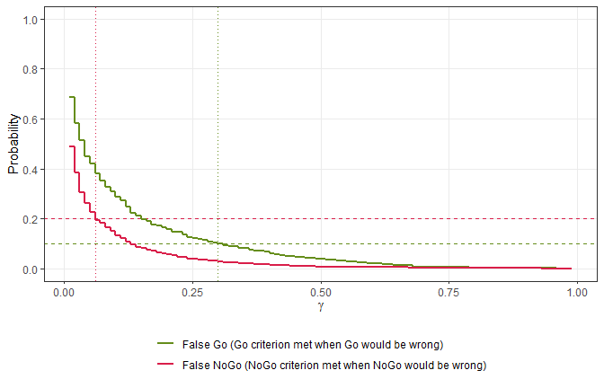

```r
plot(cal)
```

With `nsim = 1000`, the probability of meeting the Go criterion with the chosen $\gamma_{go}$, 0.100, is close to the target, so another seed or a larger `nsim` can give another threshold (see “Random numbers” in `vignette("overview")`).

## References

Yamaguchi, Y., Homma, G., Takeda, K. and Maruo, K. (submitted). Moment-matching approximation for t-differences in clinical trials with continuous endpoints.

Yamaguchi, Y., Hu, H., Huang, Y., Han, C., Homma, G. and Wang, A. (submitted). Bivariate Bayesian quantitative decision-making for two endpoints in rare disease drug development.